# Addressing the Need for and Fiscal Limitations of Chicago’s Overnight Train Service

# Background

Research on late-shift mobility shows that overnight transit service functions as essential economic and social infrastructure rather than an amenity. A 2020 American Public Transportation Association (APTA) study finds that late-shift workers, concentrated in healthcare, hospitality, airport operations, warehousing, building services, and manufacturing, face disproportionate transportation burdens when transit does not operate during overnight hours. The report argues that inadequate night service forces many workers toward car ownership they often cannot afford, contributes to higher rates of absenteeism and turnover, and ultimately imposes economic losses on employers and regional economies. Because these workers are disproportionately low-income and people of color, APTA frames overnight public transit as central to both economic competitiveness and mobility equity. Zalewski et al. (2025)

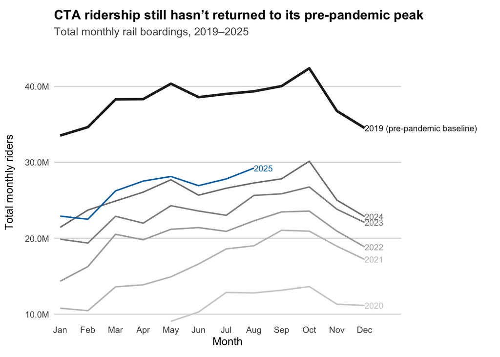

Figure 1: CTA monthly ridership has grown since the pandemic but remains far below the 2019 baseline, even as operating costs rise.  
wJake Cox / DePaul University; “CTA Ridership: Daily Boarding Totals” (2025)

This literature and policy context show that Chicago’s overnight rail service sits at the intersection of three forms of sustainability: economic (supporting the city’s night-shift labor market), social (serving transit-dependent workers and communities), and fiscal (operating within a tighter budget than in decades past). These pressures reflect the need to evaluate and optimize overnight Red, Blue, and newly 24-hour Orange Line service so the CTA can maintain essential mobility while avoiding future budget crises.